# BIOS 611 HW10 Model basics (Chapters 23 and 24)

Ty Darnell

12/03/2018

This homework is due at 6 pm on Monday, December 3.

This set of exercise is largely taken from R for Data Science by Garrett Grolemund and Hadley Wickham.

# Exercise 1

1. One downside of the linear model is that it is sensitive to unusual values because the distance incorporates a squared term. Fit a linear model to the simulated data below, and visualise the results. Rerun a few times to generate different simulated datasets. What do you notice about the model?

   ```r
   set.seed(1)
   sim1a <- tibble(
     x = rep(1:10, each = 3),
     y = x * 1.5 + 6 + rt(length(x), df = 2)
   )
   ```

   Answer:

   ```r
   simt <- function(i) {
     tibble(
   x = rep(1:10, each = 3),
   y = x * 1.5 + 6 + rt(length(x), df = 2),
   .id = i
     )
   }
   for (i in 1:12) {
   sim1a <- tibble(
     x = rep(1:10, each = 3),
     y = x * 1.5 + 6 + rt(length(x), df = 2)
   )
   print(coef(lm(y~x,sim1a)))
   }
   ```

   ```
   ## (Intercept)           x
   ##    4.696125    1.681680
   ## (Intercept)           x
   ##    3.104568    1.826557
   ## (Intercept)           x
   ##    5.384462    1.644097
   ## (Intercept)           x
   ##    7.005980    1.317059
   ## (Intercept)           x
   ##    7.077840    1.307895
   ## (Intercept)           x
   ##    7.537763    1.244080
   ## (Intercept)           x
   ##   7.3331894   0.9959618
   ## (Intercept)           x
   ##    6.558504    1.495669
   ## (Intercept)           x
   ##    6.111761    1.520228
   ## (Intercept)           x
   ##    6.778133    1.483807
   ## (Intercept)           x
   ##    7.009876    1.260882
   ## (Intercept)           x
   ##   8.4399158   0.9925414
   ```

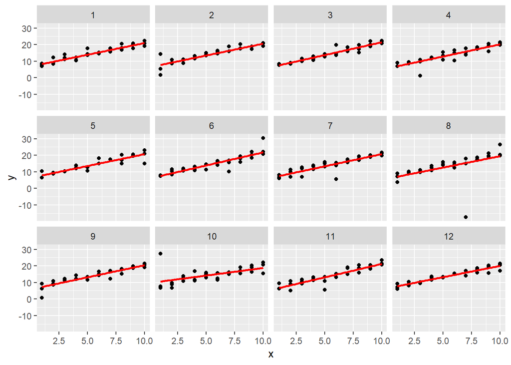

   ```r
   sims <- map_df(1:12, simt)


   ggplot(sims, aes(x = x, y = y)) +
     geom_point() +
     geom_smooth(method = "lm",se=F, colour = "red") +
     facet_wrap(~ .id, ncol = 4)
   ```

The slope and the intercept of the models are fairly different through out the simulations.

2. There are multiple ways to get the MSE (mean squared error. i.e. $\sum_{i=1}^{n} \frac {(y_i - \hat{y}_i)^2}{n - p}$ where $n$ is the sample  
   size, $p$ is the number of covariates plus 1). from an `lm` object.  
   Illustrate three different ways of getting the MSE from the following object.

   ```r
   sim1_mod <- lm(y~x, data = modelr::sim1)
   ```

   Hint: 1) using `predict()`,  
   2) extracting `residual`,  
   3) using `summary()` to get some quantity related to MSE.  
   If you are not sure what the object contains, use `str()`.

   Answer:

   ```r
   (predict(sim1_mod,se.fit = T)$residual.scale)^2
   ```

   ```
   ## [1] 4.852664
   ```

   ```r
   sum(sim1_mod$residuals^2)/28
   ```

   ```
   ## [1] 4.852664
   ```

   ```r
   summary(sim1_mod)$sigma^2
   ```

   ```
   ## [1] 4.852664
   ```

# Exercise 2

1. Instead of using `lm()` to fit a straight line, you can use `loess()` to fit a smooth curve. Repeat the process of model fitting, grid generation, predictions, and visualisation on `modelr::sim1` using `loess()` instead of `lm()`. How does the result compare to `geom_smooth()`?

   Answer:

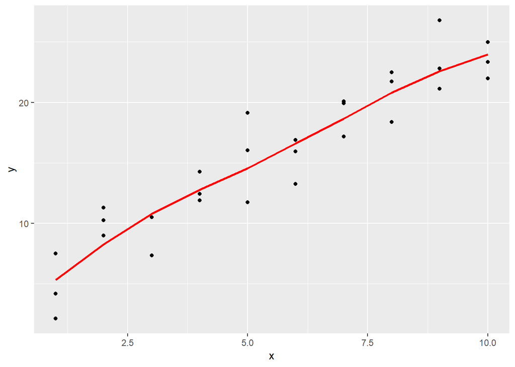

   ```r
   sim1l = loess(y ~ x, data = sim1)

   grid <- sim1 %>%
     data_grid(x)

   #add predictions
   grid <- grid %>%
     add_predictions(sim1l)

   ggplot(sim1, aes(x)) +
     geom_point(aes(y = y)) +
     geom_line(aes(y = pred), data = grid, colour = "red", size = 1)
   ```

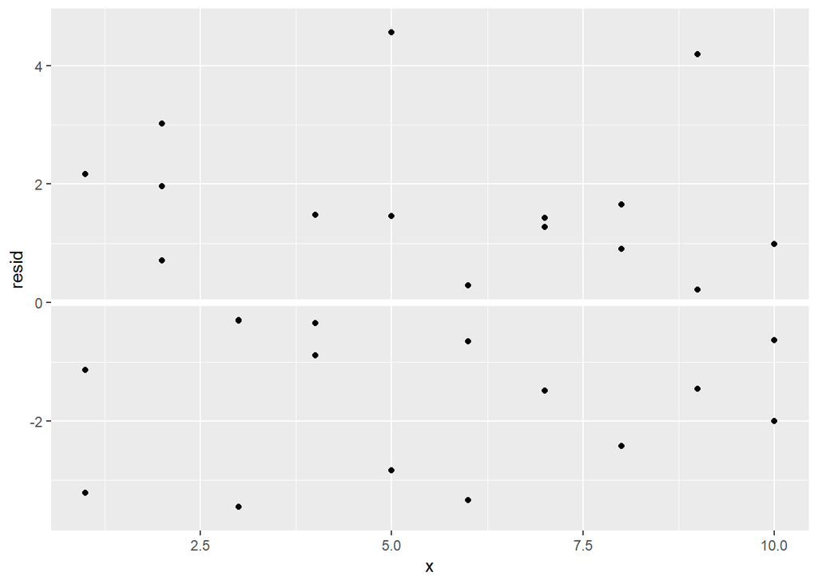

   ```r
   sim1 <- sim1 %>%
     add_residuals(sim1l)

   #plot resid against x
   ggplot(sim1, aes(x, resid)) +
     geom_ref_line(h = 0) +
     geom_point()
   ```

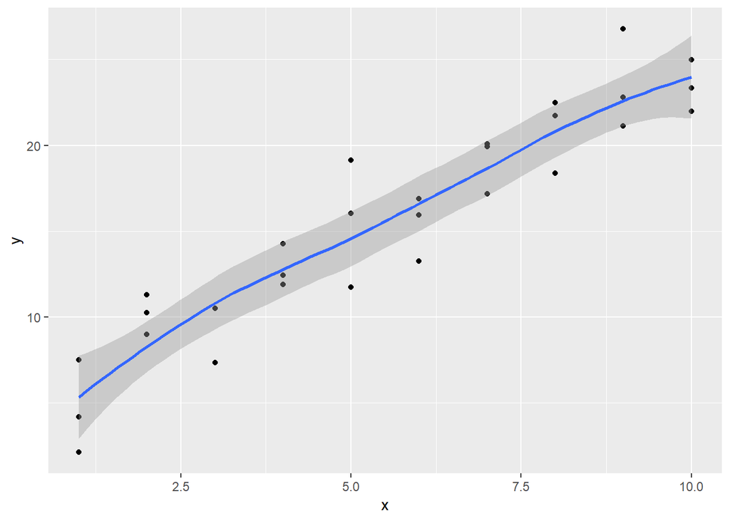

   ```r
   #compare to geom_smooth
   ggplot(sim1,aes(x=x,y=y))+
     geom_point()+
     geom_smooth()
   ```

Geom_smooth uses loess by default to fit the curve. This explains why the results are the same

2. What does `geom_ref_line()` do? What package does it come from? Why is displaying a reference line in plots showing residuals useful and important?

   Answer: `geom_ref_line()` comes from `modelr`, it adds a reference line to a ggplot. 0 is an important reference line on a residual plot. We want to see how far above or below the actual value the predicted value is.
3. In high-dimensional settings, some extension to linear models have been  
   developed to control the effect of noise variables. LASSO, ridge regression, and elastic nets are such examples. Fit usual linear model, LASSO, and ridge regression using `mtcars` data: i.e. `lm(mpg ~ ., mtcars)` for usual linear model. Use `glmnet::glmnet()` with `alpha = 1` for LASSO and `alpha = 0` for ridge regression.  
   To find the best amount of penalty (`lambda`), usually cross validation is done, but here, simply put `lambda = 0.6`.  
   What is the main difference bewteen LASSO and ridge regression? (Look at their coefficients using `coef()` function. Keyword: sparsity)

   Answer:

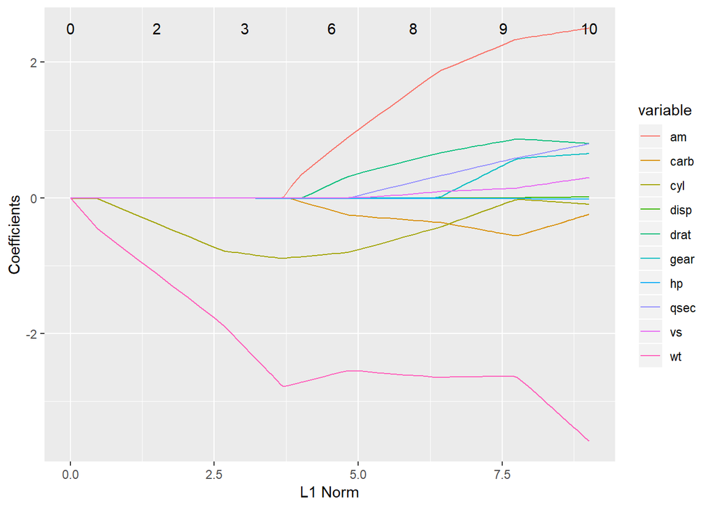

   ```r
   lmmod=lm(mpg~.,mtcars)
   lasso <- glmnet(as.matrix(mtcars[-1]), mtcars$mpg, alpha=1)
   ridge <- glmnet(as.matrix(mtcars[-1]), mtcars$mpg, alpha=0)
   autoplot(lasso)
   ```

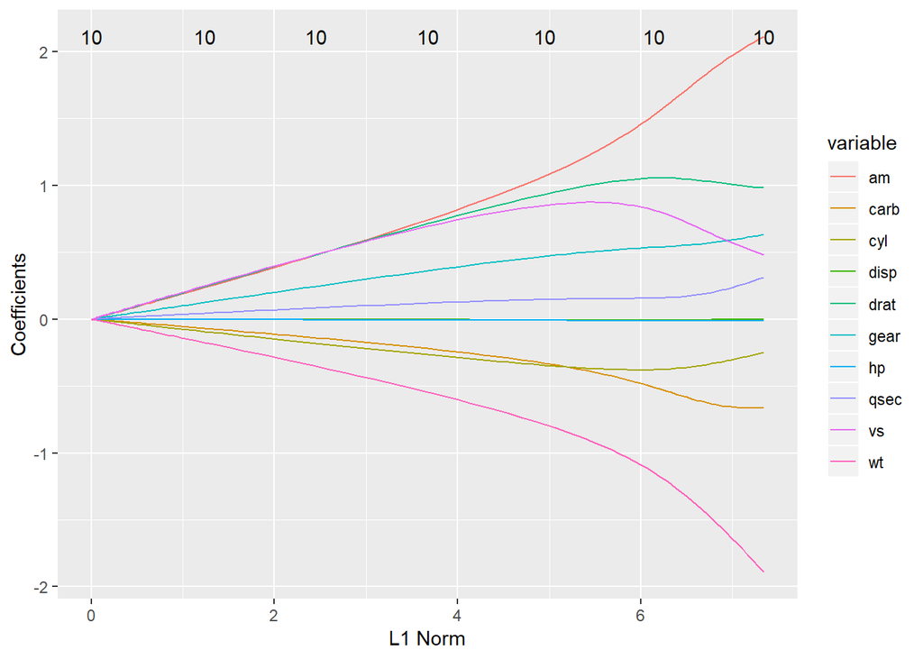

   ```r
   autoplot(ridge)
   ```

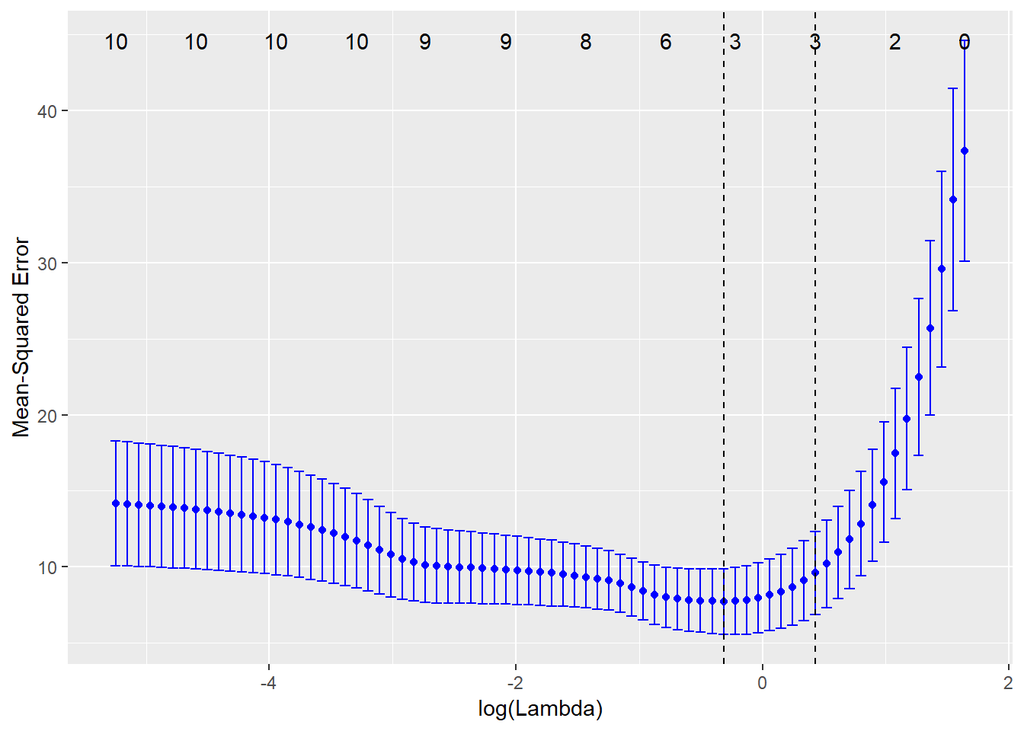

   ```r
   lassocv <- cv.glmnet(as.matrix(mtcars[-1]), mtcars$mpg, alpha=1)
   ridgecv <- cv.glmnet(as.matrix(mtcars[-1]), mtcars$mpg, alpha=0)
   autoplot(lassocv, color = 'blue')
   ```

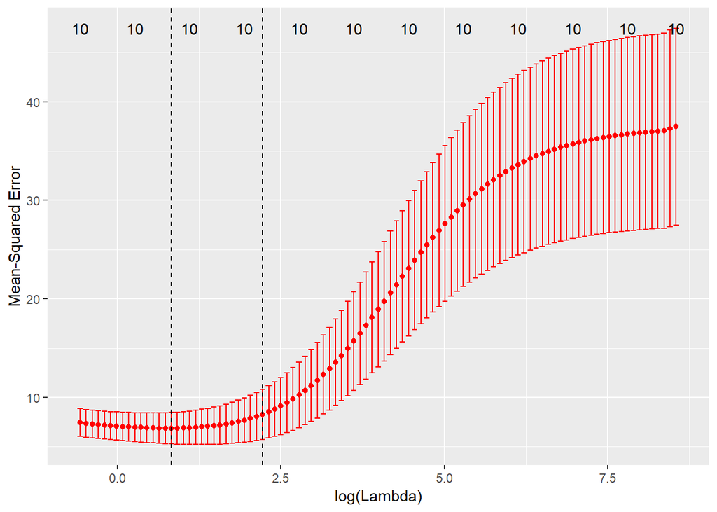

   ```r
   autoplot(ridgecv, color = 'red')
   ```

Creating lasso and ridge regression models with $\lambda=.6$

```r
lasso2 <- glmnet(as.matrix(mtcars[-1]), mtcars$mpg, alpha=1,lambda=.6)
ridge2 <- glmnet(as.matrix(mtcars[-1]), mtcars$mpg, alpha=0,lambda=.6)
coef(lasso2)
```

```
## 11 x 1 sparse Matrix of class "dgCMatrix"
##                      s0
## (Intercept) 36.37233176
## cyl         -0.87504916
## disp         .
## hp          -0.01381246
## drat         .
## wt          -2.75560978
## qsec         .
## vs           .
## am           0.18645277
## gear         .
## carb        -0.01830616
```

```r
coef(ridge2)
```

```
## 11 x 1 sparse Matrix of class "dgCMatrix"
##                       s0
## (Intercept) 19.868338922
## cyl         -0.267737711
## disp        -0.002480752
## hp          -0.012879142
## drat         0.988174613
## wt          -1.814034228
## qsec         0.288314837
## vs           0.499765989
## am           2.071361065
## gear         0.619414622
## carb        -0.664047236
```

# Exercise 3

1. Write a model formula in `lm()` in R that represents the following formula:  
   $E[y|x_1, x_2] = \beta_0 + \beta_1x_1 + \beta_2x_1^2 + \beta_3x_1x_2 + \beta_4e^{x_1}$.  
   Note: Beware that there is no main effect term for $x_2$.  
   Use the following data (`dat`).

   ```r
   set.seed(1)
   dat <- data_frame(x1 = rnorm(30), x2 = rnorm(30), y = x1*(x1-x2) - exp(x1)/3 + rnorm(30))
   ```

   Answer:

   ```r
   modw <- lm(y~x1*x2-x2+I(x1^2)+exp(x1),dat)
   summary(modw)
   ```

   ```
   ##
   ## Call:
   ## lm(formula = y ~ x1 * x2 - x2 + I(x1^2) + exp(x1), data = dat)
   ##
   ## Residuals:
   ##     Min      1Q  Median      3Q     Max
   ## -1.8145 -0.3434 -0.1856  0.3922  1.7006
   ##
   ## Coefficients:
   ##             Estimate Std. Error t value Pr(>|t|)
   ## (Intercept)  -1.5382     0.8382  -1.835   0.0784 .
   ## x1           -2.8908     1.1384  -2.539   0.0177 *
   ## I(x1^2)      -0.3364     0.4390  -0.766   0.4506
   ## exp(x1)       1.6533     0.8267   2.000   0.0565 .
   ## x1:x2        -1.2073     0.2336  -5.169 2.41e-05 ***
   ## ---
   ## Signif. codes:  0 '***' 0.001 '**' 0.01 '*' 0.05 '.' 0.1 ' ' 1
   ##
   ## Residual standard error: 0.8355 on 25 degrees of freedom
   ## Multiple R-squared:  0.7095, Adjusted R-squared:  0.663
   ## F-statistic: 15.27 on 4 and 25 DF,  p-value: 1.92e-06
   ```

2. Suppose for some reason, you do not want to include an intercept term in your linear model. e.g. $E[y|x_1] = \beta_1x_1$.

   A. How would you remove the intercept in `lm()`? Write a code for such a model (Use the same dataset (`dat`)).

   Answer:

   ```r
   lm(y~x1-1,dat)
   ```

   ```
   ##
   ## Call:
   ## lm(formula = y ~ x1 - 1, data = dat)
   ##
   ## Coefficients:
   ##      x1
   ## -0.7011
   ```

   B. Compare and contrast models with and without the intercept term using  
   `modelr::sim1`. Plot the predicted values for comaparison.

   Answer:

   ```r
   mod1=lm(y~x,sim1)
   mod1a=lm(y~x-1,sim1)
   sim1 %>%
     data_grid(x) %>%
     spread_predictions(mod1, mod1a)
   ```

   ```
   ## # A tibble: 10 x 3
   ##        x  mod1 mod1a
   ##    <int> <dbl> <dbl>
   ##  1     1  6.27  2.65
   ##  2     2  8.32  5.31
   ##  3     3 10.4   7.96
   ##  4     4 12.4  10.6
   ##  5     5 14.5  13.3
   ##  6     6 16.5  15.9
   ##  7     7 18.6  18.6
   ##  8     8 20.6  21.2
   ##  9     9 22.7  23.9
   ## 10    10 24.7  26.5
   ```

The results are different, creating a model with an intercept and one without an intercept

[output not shown]

# Exercise 4

1. Using the data `daily` given below, do the following.  
   Create a new variable that splits the `wday` variable into terms, but only for Saturdays, i.e. it should have `Thurs`, `Fri`, but `Sat-summer`, `Sat-spring`, `Sat-fall`. How does this model (`lm()` with `n` as the outcome) compare with the model with every combination of `wday` and `term`?

   ```r
   term <- function(date) {
     cut(date, breaks = lubridate::ymd(20130101, 20130605, 20130825, 20140101),
         labels = c("spring", "summer", "fall"))
     }
   daily <- nycflights13::flights %>%
     mutate(date = lubridate::make_date(year, month, day)) %>%
     group_by(date) %>%
     summarise(n = n()) %>%
     mutate(wday = lubridate::wday(date, label = TRUE),
            term = term(date))
   ```

   Answer:

   ```r
   daily <- daily %>%
     mutate(wday2 =
        case_when(wday == "Sat" & term == "summer" ~ "Sat-summer",
                  wday == "Sat" & term == "fall" ~ "Sat-fall",
                  wday == "Sat" & term == "spring" ~ "Sat-spring",
                  TRUE ~ as.character(wday)))
   moddaily <- lm(n ~ wday2, data = daily)
   ```

2. Create a new `wday` variable that combines the day of week, term (for Saturdays), and public holidays. What do the residuals of that model look like?

   Answer:
3. What happens if you fit a day of week effect that varies by month (i.e. `n ~ wday * month`)? Why is this not very helpful?

   ```r
   daily <- mutate(daily, month = lubridate::month(date))
   lm(n ~ wday * month, data = daily)
   ```

   ```
   ##
   ## Call:
   ## lm(formula = n ~ wday * month, data = daily)
   ##
   ## Coefficients:
   ##  (Intercept)        wday.L        wday.Q        wday.C        wday^4
   ##     910.7396      -60.5489     -163.9763      -59.6289      -76.8460
   ##       wday^5        wday^6         month  wday.L:month  wday.Q:month
   ##      -2.6829      -10.3739        1.8086       -3.4518        1.3290
   ## wday.C:month  wday^4:month  wday^5:month  wday^6:month
   ##      -0.4962       -0.4768       -0.3647       -1.0113
   ```

4. What would you expect the model `n ~ wday + ns(date, 5)` to look like? Knowing what you know about the data, why would you expect it to be not particularly effective?

   Answer:
5. It’s a little frustrating that Sunday and Saturday are on separate ends of the plot. Write a small function to set the levels of the factor so that the week starts on Monday.

   Answer:

# Exercise 5 `caret`

1. Using the `iris` dataset, find which machine learning algorithm gives the best prediction accuracy for predicting `Species` among `knn`, `rf` (randomForest), and `nnet` (neuralnet).

   Show a) how you partition the data (training and test sets), b) how you train the models, and c) how you evaluate the models.

   Fix the seed number within each chunk as needed for replication.  
   You do not have to customize the tuning parameters (i.e. use the default set).  
   Standardize the dataset before training using `preProcess()` or `train(..., preProcess = ...)`.

   Answer: